# Simulation Results: training: 3 studies; testing: 1 study

Ning Leng

2020-01-14

Trial 1 - 3: training (200 patients each)

Trial 4: testing (800 patients)

a.0 causal

bootstrap correction and leave one study out CV implemented(loo.cv)

# 1 Simulation structure

```r
for(i in 1:4){
  cat(paste0("## Heatmap: Simu ", i, ":", section.names[i],"\n\n\n"))
  simutmp <- get(paste0("simu.",i))
  heat.fun(simutmp[[1]])
  #print(summary.cor(simutmp[[1]]))
}
```

## 1.1 Heatmap: Simu 1:No shift, same cor, same coef

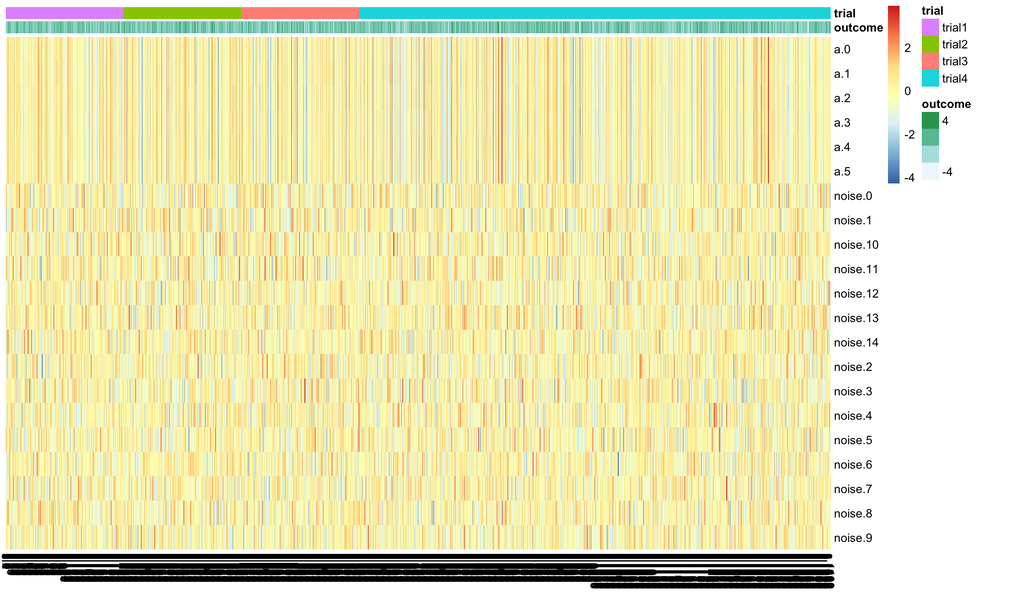

## Heatmap: Simu 2:No shift, different cor, same coef

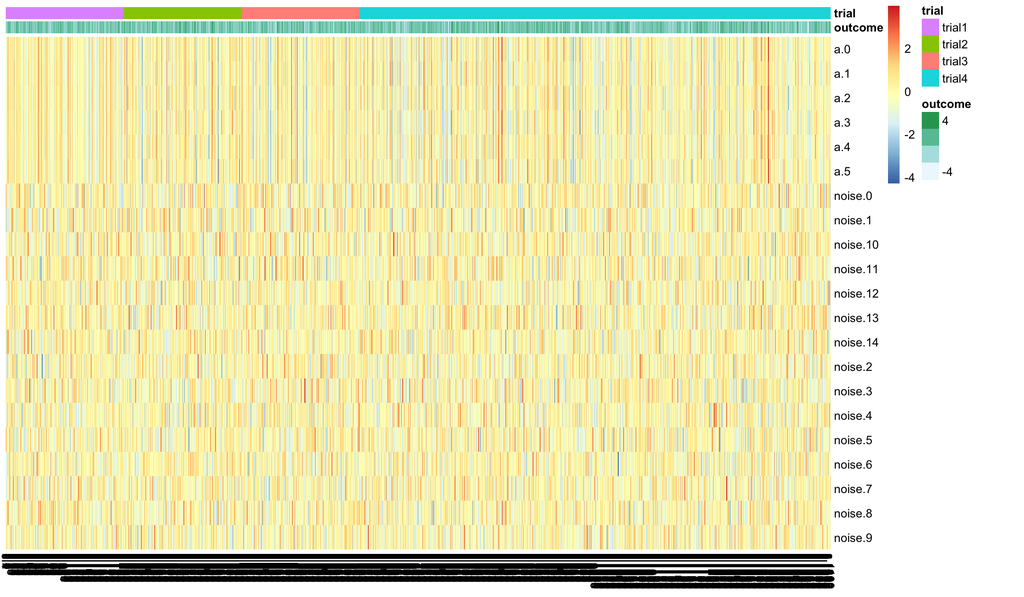

## Heatmap: Simu 3:No shift, same cor, diff coef

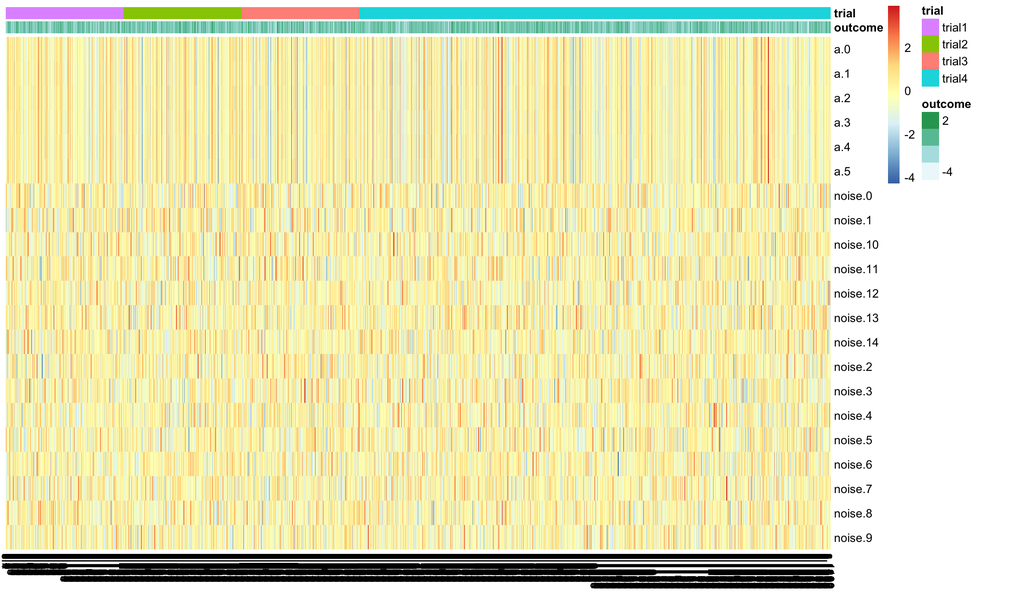

## Heatmap: Simu 4:With shift, same cor, same coef

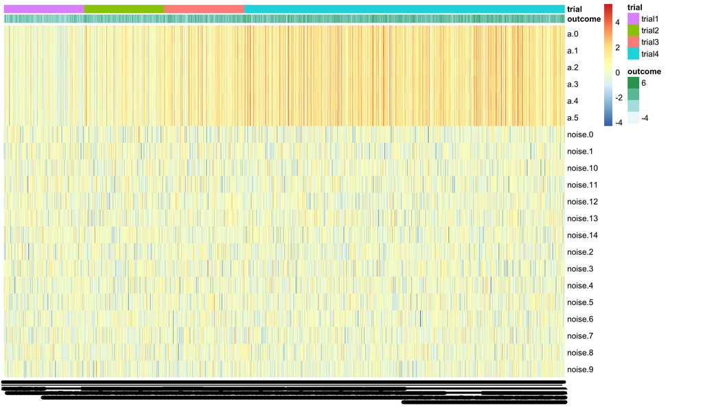

# 2 Analysis, all x observed

```r
for(i in 1:4){
  cat(paste0("## Simu ", i, ":", section.names[i],"\n\n\n"))
  for(obs.subset in c(TRUE)){
    suffix <- ifelse(obs.subset,"","noa0")
    simuname.out <- paste0("simu_multistudies.",i, suffix)
    cat(paste0("Causal feacture observed? ", obs.subset, '\n\n\n'))

    cat("### Top selected features \n\n\n")
    res.v <- readRDS(paste0(simuname.out, ".res.v.rds"))
    lasso.top <- sapply(res.v, function(i)i$lasso.top.names[1])
    print(table(lasso.top))
    cat("\n\n\n")

    uni.top <- sapply(res.v, function(i)i$uni.top.names[1])
    print(table(uni.top))
    cat("\n\n\n")
    cat("### MSE \n\n\n")
    mse.plot.df <- readRDS(paste0(simuname.out,".mse.plot.df.rds"))
    mse.tab <- mse.plot.df %>% group_by(model, method) %>% summarise(mean=mean(mse), median=median(mse))
    print(kable(mse.tab))
    cat("\n\n\n")

  }
}
```

## 2.1 Simu 1:No shift, same cor, same coef

Causal feacture observed? TRUE

### 2.1.1 Top selected features

lasso.top a.0 a.3 a.5 8 1 1

uni.top a.0 a.3 9 1

### 2.1.2 MSE

| model | method | mean | median |
| --- | --- | --- | --- |
| lasso | lasso.trial1 | 0.9841572 | 0.9782579 |
| lasso | lasso.trial2 | 1.0000770 | 1.0017186 |
| lasso | lasso.trial1.bootcorrection | 1.0610500 | 1.0804558 |
| lasso | lasso.trial1.loo.cv.correction | 1.0187442 | 1.0031350 |
| unitop | unitop.trial1 | 0.9880045 | 0.9880871 |
| unitop | unitop.trial2 | 0.9911417 | 0.9989435 |
| unitop | unitop.trial1.bootcorrection | 0.9963856 | 1.0131583 |
| unitop | unitop.trial1.loo.cv.correction | 1.0084514 | 1.0027848 |

## 2.2 Simu 2:No shift, different cor, same coef

Causal feacture observed? TRUE

### 2.2.1 Top selected features

lasso.top a.0 10

uni.top a.0 10

### 2.2.2 MSE

| model | method | mean | median |
| --- | --- | --- | --- |
| lasso | lasso.trial1 | 0.9831565 | 0.9743553 |
| lasso | lasso.trial2 | 1.0066894 | 1.0116079 |
| lasso | lasso.trial1.bootcorrection | 1.0603940 | 1.0736339 |
| lasso | lasso.trial1.loo.cv.correction | 1.0189394 | 0.9986108 |
| unitop | unitop.trial1 | 0.9881322 | 0.9880871 |
| unitop | unitop.trial2 | 0.9906175 | 0.9963228 |
| unitop | unitop.trial1.bootcorrection | 0.9883948 | 1.0072044 |
| unitop | unitop.trial1.loo.cv.correction | 0.9983664 | 0.9930002 |

## 2.3 Simu 3:No shift, same cor, diff coef

Causal feacture observed? TRUE

### 2.3.1 Top selected features

lasso.top a.0 a.3 a.5 7 1 2

uni.top a.0 a.3 a.5 8 1 1

### 2.3.2 MSE

| model | method | mean | median |
| --- | --- | --- | --- |
| lasso | lasso.trial1 | 1.020925 | 0.9945068 |
| lasso | lasso.trial2 | 1.010420 | 1.0168826 |
| lasso | lasso.trial1.bootcorrection | 1.102419 | 1.1139743 |
| lasso | lasso.trial1.loo.cv.correction | 1.110154 | 1.0649434 |
| unitop | unitop.trial1 | 1.023123 | 1.0095787 |
| unitop | unitop.trial2 | 1.032457 | 1.0390028 |
| unitop | unitop.trial1.bootcorrection | 1.033500 | 1.0464232 |
| unitop | unitop.trial1.loo.cv.correction | 1.098002 | 1.0662415 |

## 2.4 Simu 4:With shift, same cor, same coef

Causal feacture observed? TRUE

### 2.4.1 Top selected features

lasso.top a.0 a.1 a.2 a.3 a.4 2 1 2 3 2

uni.top a.0 a.1 a.2 a.3 a.4 5 1 1 1 2

### 2.4.2 MSE

| model | method | mean | median |
| --- | --- | --- | --- |
| lasso | lasso.trial1 | 0.9745858 | 0.9592586 |
| lasso | lasso.trial2 | 1.0319500 | 1.0389607 |
| lasso | lasso.trial1.bootcorrection | 1.0683881 | 1.0533666 |
| lasso | lasso.trial1.loo.cv.correction | 1.0142043 | 0.9870395 |
| unitop | unitop.trial1 | 0.9813318 | 0.9558785 |
| unitop | unitop.trial2 | 1.0174230 | 1.0221632 |
| unitop | unitop.trial1.bootcorrection | 1.0117872 | 0.9803192 |
| unitop | unitop.trial1.loo.cv.correction | 1.0023771 | 0.9803925 |

# 3 Analysis, a.0 (causal) not observed

```r
for(i in 1:4){
  cat(paste0("## Simu ", i, ":", section.names[i],"\n\n\n"))
  for(obs.subset in c(FALSE)){
    suffix <- ifelse(obs.subset,"","noa0")
    simuname.out <- paste0("simu_multistudies.",i, suffix)
    cat(paste0("Causal feacture observed? ", obs.subset, '\n\n\n'))

    cat("### Top selected features \n\n\n")
    res.v <- readRDS(paste0(simuname.out, ".res.v.rds"))
    lasso.top <- sapply(res.v, function(i)i$lasso.top.names[1])
    print(table(lasso.top))
    cat("\n\n\n")
    uni.top <- sapply(res.v, function(i)i$uni.top.names[1])
    print(table(uni.top))
    cat("\n\n\n")
    cat("### MSE \n\n\n")
    mse.plot.df <- readRDS(paste0(simuname.out,".mse.plot.df.rds"))
    mse.tab <- mse.plot.df %>% group_by(model, method) %>% summarise(mean=mean(mse), median=median(mse))
    print(kable(mse.tab))
        cat("\n\n\n")

  }
}
```

## 3.1 Simu 1:No shift, same cor, same coef

Causal feacture observed? FALSE

### 3.1.1 Top selected features

lasso.top a.1 a.2 a.3 a.5 4 1 3 2

uni.top a.1 a.2 a.3 a.5 3 2 3 2

### 3.1.2 MSE

| model | method | mean | median |
| --- | --- | --- | --- |
| lasso | lasso.trial1 | 0.9875050 | 0.9836235 |
| lasso | lasso.trial2 | 1.0057567 | 1.0050185 |
| lasso | lasso.trial1.bootcorrection | 1.0594546 | 1.0755996 |
| lasso | lasso.trial1.loo.cv.correction | 1.0235109 | 1.0152638 |
| unitop | unitop.trial1 | 0.9965216 | 0.9962178 |
| unitop | unitop.trial2 | 1.0056017 | 1.0002089 |
| unitop | unitop.trial1.bootcorrection | 1.0118715 | 1.0219954 |
| unitop | unitop.trial1.loo.cv.correction | 1.0221552 | 1.0129821 |

## 3.2 Simu 2:No shift, different cor, same coef

Causal feacture observed? FALSE

### 3.2.1 Top selected features

lasso.top a.1 a.2 a.3 a.4 a.5 3 1 2 1 3

uni.top a.1 a.2 a.3 a.4 a.5 3 1 3 1 2

### 3.2.2 MSE

| model | method | mean | median |
| --- | --- | --- | --- |
| lasso | lasso.trial1 | 1.003583 | 1.001295 |
| lasso | lasso.trial2 | 1.068415 | 1.063380 |
| lasso | lasso.trial1.bootcorrection | 1.085016 | 1.102478 |
| lasso | lasso.trial1.loo.cv.correction | 1.048881 | 1.047282 |
| unitop | unitop.trial1 | 1.049082 | 1.042515 |
| unitop | unitop.trial2 | 1.195719 | 1.185739 |
| unitop | unitop.trial1.bootcorrection | 1.084917 | 1.072164 |
| unitop | unitop.trial1.loo.cv.correction | 1.097212 | 1.074403 |

## 3.3 Simu 3:No shift, same cor, diff coef

Causal feacture observed? FALSE

### 3.3.1 Top selected features

lasso.top a.1 a.2 a.3 a.5 3 1 3 3

uni.top a.1 a.2 a.3 a.5 3 1 3 3

### 3.3.2 MSE

| model | method | mean | median |
| --- | --- | --- | --- |
| lasso | lasso.trial1 | 1.022809 | 0.9965718 |
| lasso | lasso.trial2 | 1.012356 | 1.0148222 |
| lasso | lasso.trial1.bootcorrection | 1.097408 | 1.1134953 |
| lasso | lasso.trial1.loo.cv.correction | 1.112225 | 1.0636948 |
| unitop | unitop.trial1 | 1.027679 | 1.0138718 |
| unitop | unitop.trial2 | 1.037422 | 1.0394613 |
| unitop | unitop.trial1.bootcorrection | 1.041521 | 1.0479904 |
| unitop | unitop.trial1.loo.cv.correction | 1.104941 | 1.0663407 |

## 3.4 Simu 4:With shift, same cor, same coef

Causal feacture observed? FALSE

### 3.4.1 Top selected features

lasso.top a.1 a.2 a.3 a.4 a.5 1 2 2 4 1

uni.top a.1 a.2 a.3 a.4 a.5 1 2 2 4 1

### 3.4.2 MSE

| model | method | mean | median |
| --- | --- | --- | --- |
| lasso | lasso.trial1 | 0.9751843 | 0.9598505 |
| lasso | lasso.trial2 | 1.0346535 | 1.0450263 |
| lasso | lasso.trial1.bootcorrection | 1.0664738 | 1.0502572 |
| lasso | lasso.trial1.loo.cv.correction | 1.0145752 | 0.9865614 |
| unitop | unitop.trial1 | 0.9835751 | 0.9609597 |
| unitop | unitop.trial2 | 1.0327769 | 1.0501154 |
| unitop | unitop.trial1.bootcorrection | 1.0165083 | 0.9786601 |
| unitop | unitop.trial1.loo.cv.correction | 1.0076436 | 0.9911008 |